# Antigen processing on Google Scholar

This ended up being is as much about what scraping data from Google Scholar can’t do, as what it can. However, hopefully it is not completely uninformative and provides a way into the literature for uninitiated.

### Summary

What follows was inspired by a blog post by Jeff Leek from [Simply Statistics](http://simplystatistics.org/2015/01/16/if-you-were-going-to-write-a-paper-about-the-false-discovery-rate-you-should-have-done-it-in-2002/). I’ve hacked his code to my own ends here, and you can find all the code for and raw data for doing something similar on my [GitHub repo](https://github.com/ab604/ap-stats).

The aim was to get a sense of what has happened/is happening in the field of MHC class I antigen processing by scraping the top hits from Google Scholar for a collection of antigen processing related terms. [About Google Scholar](http://scholar.google.co.uk/intl/en/scholar/about.html) suggests Google Scholar is driven largely by citations.

By examining when the most cited papers were published it provides a sense of when the key discoveries were made, and which topics are hot or cold. (Which might be handy for choosing future work).

**However** I also discovered that Google is very sensitive to the search terms and whilst scraping the most cited papers is easy, they aren’t necessarily the most relevant, especially where MHC I is concerned.

If you are familiar with the field, the results may seem intuitive. Indeed you may be able to map your own career to the timings of the publications. Or you may just be infuriated that I didn’t find the papers you consider the most important. :-)

Below you can see what I did and what I found in the form of box-plots and some interactive tables.

### Search terms used

Initially I searched on 8 search terms for the **key players** in the MHC I antigen processing pathway. These terms were:

```
[1] ERAP1 aminopeptidase
[2] tapasin
[3] major histocompatibility complex class I molecule -II
[4] calreticulin
[5] erp57 reductase
[6] calnexin
[7] TAPBPR tapasin-related protein
[8] UGGT glucosyltransferase
```

And then I did a second round for **MHC I specific** search terms to split MHC I papers into categories using the original search term, and then for paper to do with structure, conformation change and peptide repertoire. These terms were:

```
[1] intext:major histocompatibility complex class I molecule -II -III -polymerase -nonclassical
[2] Structure of the human class i histocompatibility antigen -II -nonclassical -gene -antibody -plate -placenta -CDlb -genetics -Fc -DR1
[3] intext:mhc class I conformational -II -genes
[4] histocompatibility class i peptide repertoire -II -antibodies -Ib
```

### Boxplots of the search results

Having performed the searches I’ve plotted the results as box-plots for the key players:

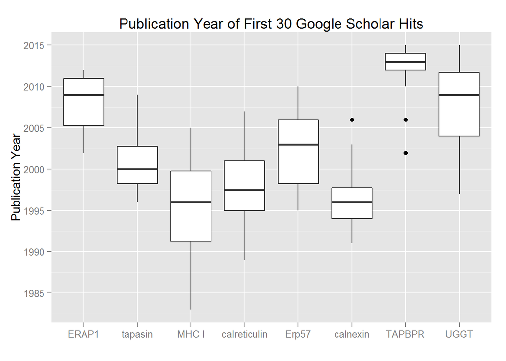

The median publication date for each category is:

```
       ERAP1      tapasin        MHC I calreticulin        Erp57
        2009         2000         1996         1998         2003
    calnexin       TAPBPR         UGGT
        1996         2013         2009
```

And here’s box-plot for the MHC I categories MHC I molecule, MHC I structure, MHC I conformational change and MHC I peptide repertoire:

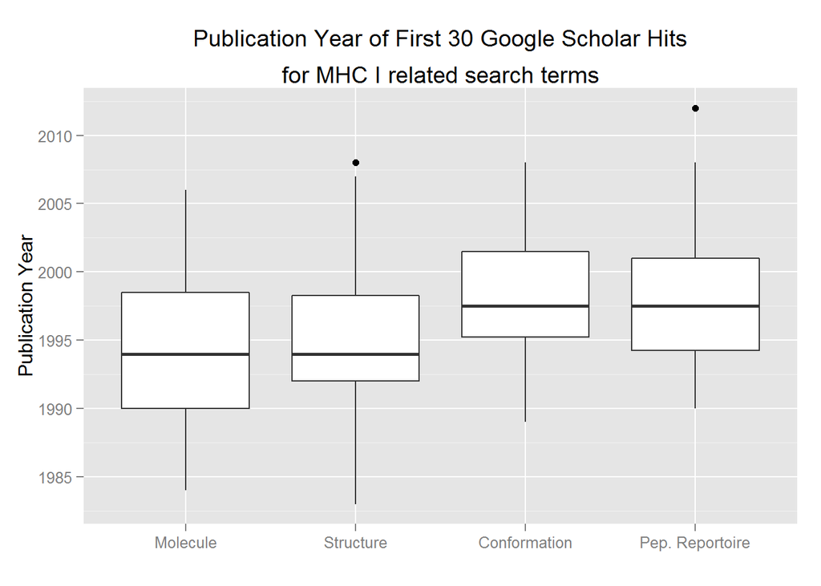

With the median publication dates for these categories:

```
       Molecule       Structure    Conformation Pep. Reportoire
           1994            1994            1998            1998
```

### Tables of the papers scraped for each search

#### ERAP1

| First Author | Paper Title | Publication Year | No. of Citations |
| --- | --- | --- | --- |
| T Saric | An IFN- induced aminopeptidase in the ER ERAP1 trims precursors to MHC class I presented peptides | 2002 | 419 |
| IA York | The ER aminopeptidase ERAP1 enhances or limits antigen presentation by trimming epitopes to 8 9 residues | 2002 | 389 |
| L Saveanu | Concerted peptide trimming by human ERAP1 and ERAP2 aminopeptidase complexes in the endoplasmic reticulum | 2005 | 257 |
| SC Chang | The ER aminopeptidase ERAP1 trims precursors to lengths of MHC class I peptides by a molecular ruler mechanism | 2005 | 166 |
| IA York | Endoplasmic reticulum aminopeptidase 1 ERAP1 trims MHC class I-presented peptides in vivo and plays an important role in immunodominance | 2006 | 114 |
| G Kochan | Crystal structures of the endoplasmic reticulum aminopeptidase-1 ERAP1 reveal the molecular basis for N-terminal peptide trimming | 2011 | 81 |
| TT Nguyen | Structural basis for antigenic peptide precursor processing by the endoplasmic reticulum aminopeptidase ERAP1 | 2011 | 72 |
| S Kim | Human cytomegalovirus microRNA miR-US4-1 inhibits CD8+ T cell responses by targeting the aminopeptidase ERAP1 | 2011 | 71 |
| D Fruci | Altered expression of endoplasmic reticulum aminopeptidases ERAP1 and ERAP2 in transformed non lymphoid human tissues | 2008 | 51 |
| AM Mehta | Single nucleotide polymorphisms in antigen processing machinery component ERAP1 significantly associate with clinical outcome in cervical carcinoma | 2009 | 45 |

[output cut: 20 more lines]

#### Tapasin

| First Author | Paper Title | Publication Year | No. of Citations |
| --- | --- | --- | --- |
| B Sadasivan | Roles for calreticulin and a novel glycoprotein tapasin in the interaction of MHC class I molecules with TAP | 1996 | 641 |
| B Ortmann | A critical role for tapasin in the assembly and function of multimeric MHC class I-TAP complexes | 1997 | 472 |
| N Bangia | The N terminal region of tapasin is required to stabilize the MHC class I loading complex | 1999 | 172 |
| PJ Lehner | Soluble tapasin restores MHC class I expression and function in the tapasin-negative cell line 220 | 1998 | 288 |
| AP Williams | Optimization of the MHC class I peptide cargo is dependent on tapasin | 2002 | 265 |
| CA Peh | HLA-B27 restricted antigen presentation in the absence of tapasin reveals polymorphism in mechanisms of HLA class I peptide loading | 1998 | 229 |
| N Garbi | Impaired immune responses and altered peptide repertoire in tapasin-deficient mice | 2000 | 190 |
| VM Braud | TAP-and tapasin-dependent HLA-E surface expression correlates with the binding of an MHC class I leader peptide | 1998 | 197 |
| AG Grandea | Impaired assembly yet normal trafficking of MHC class I molecules in Tapasin mutant mice | 2000 | 185 |
| JC Solheim | Prominence of beta 2-microglobulin class I heavy chain conformation and tapasin in the interactions of class I heavy chain with calreticulin and the transporter | 1997 | 140 |

[output cut: 20 more lines]

#### MHC I molecule

| First Author | Paper Title | Publication Year | No. of Citations |
| --- | --- | --- | --- |
| O Schwartz | Endocytosis of major histocompatibility complex class I molecules is induced by the HIV 1 Nef protein | 1996 | 908 |
| K Falk | Cellular peptide composition governed by major histocompatibility complex class I molecules | 1990 | 388 |
| D Pende | Major Histocompatibility Complex Class I-related Chain A and UL16-Binding Protein Expression on Tumor Cell Lines of Different Histotypes Analysis of Tumor | 2002 | 467 |
| A Townsend | Association of class I major histocompatibility heavy and light chains induced by viral peptides | 1989 | 983 |
| V Cerundolo | Presentation of viral antigen controlled by a gene in the major histocompatibility complex | 1990 | 369 |
| EA Hughes | Misfolded major histocompatibility complex class I heavy chains are translocated into the cytoplasm and degraded by the proteasome | 1997 | 269 |
| MH Furman | The human cytomegalovirus US10 gene product delays trafficking of major histocompatibility complex class I molecules | 2002 | 92 |
| RE Brown | The major histocompatibility complex and the chemosensory recognition of individuality in rats | 1987 | 154 |
| J Michaëlsson | Visualization of inhibitory Ly49 receptor specificity with soluble major histocompatibility complex class I tetramers | 2000 | 79 |
| GM Van Bleek | The structure of the antigen-binding groove of major histocompatibility complex class I molecules determines specific selection of self-peptides | 1991 | 95 |

[output cut: 20 more lines]

#### Calreticulin

| First Author | Paper Title | Publication Year | No. of Citations |
| --- | --- | --- | --- |
| K Burns | Modulation of gene expression by calreticulin binding to the glucocorticoid receptor | 1994 | 384 |
| MG Coppolino | Calreticulin is essential for integrin-mediated calcium signalling and cell adhesion | 1997 | 353 |
| M Obeid | Calreticulin exposure dictates the immunogenicity of cancer cell death | 2007 | 1007 |
| S Dedhar | Inhibition of nuclear hormone receptor activity by calreticulin | 1994 | 350 |
| S Basu | CD91 is a common receptor for heat shock proteins gp96 hsp90 hsp70 and calreticulin | 2001 | 1016 |
| CA Ogden | C1q and mannose binding lectin engagement of cell surface calreticulin and CD91 initiates macropinocytosis and uptake of apoptotic cells | 2001 | 926 |
| B Sadasivan | Roles for calreticulin and a novel glycoprotein tapasin in the interaction of MHC class I molecules with TAP | 1996 | 641 |
| SJ Gardai | Cell-surface calreticulin initiates clearance of viable or apoptotic cells through trans-activation of LRP on the phagocyte | 2005 | 598 |
| M Michalak | Calreticulin one protein one gene many functions | 1999 | 618 |
| M Michalak | Calreticulin | 1992 | 466 |

[output cut: 20 more lines]

#### Erp57

| First Author | Paper Title | Publication Year | No. of Citations |
| --- | --- | --- | --- |
| JD Oliver | Interaction of the thiol-dependent reductase ERp57 with nascent glycoproteins | 1997 | 347 |
| NA Morrice | A role for the thiol-dependent reductase ERp57 in the assembly of MHC class I molecules | 1998 | 145 |
| N Hirano | Molecular Cloning of the Human Glucose Regulated Protein ERp57/GRP58 a Thiol Dependent Reductase | 1995 | 126 |
| JG Elliott | The thiol-dependent reductase ERp57 interacts specifically with N-glycosylated integral membrane proteins | 1997 | 124 |
| AN Antoniou | The oxidoreductase ERp57 efficiently reduces partially folded in preference to fully folded MHC class I molecules | 2002 | 101 |
| EA Hughes | The thiol oxidoreductase ERp57 is a component of the MHC class I peptide-loading complex | 1998 | 191 |
| JD Oliver | ERp57 functions as a subunit of specific complexes formed with the ER lectins calreticulin and calnexin | 1999 | 272 |
| JA Lindquist | ER 60 a chaperone with thiol dependent reductase activity involved in MHC class I assembly | 1998 | 228 |
| L Ellgaard | Calnexin calreticulin and ERp57 | 2003 | 142 |
| FJ van der Wal | The transient association of ERp57 with N glycosylated proteins is regulated by glucose trimming | 1998 | 41 |

[output cut: 20 more lines]

#### Calnexin

| First Author | Paper Title | Publication Year | No. of Citations |
| --- | --- | --- | --- |
| WJ Ou | Association of folding intermediates of glycoproteins with calnexin during protein maturation | 1993 | 539 |
| JJM Bergeron | Calnexin a membrane-bound chaperone of the endoplasmic reticulum | 1994 | 505 |
| DN Hebert | Glucose trimming and reglucosylation determine glycoprotein association with calnexin in the endoplasmic reticulum | 1995 | 492 |
| MR Jackson | Regulation of MHC class I transport by the molecular chaperone calnexin p88 IP90 | 1994 | 259 |
| C Hammond | Role of N-linked oligosaccharide recognition glucose trimming and calnexin in glycoprotein folding and quality control | 1994 | 677 |
| S Rajagopalan | Retention of unassembled components of integral membrane proteins by calnexin | 1994 | 234 |
| M Molinari | Role of EDEM in the release of misfolded glycoproteins from the calnexin cycle | 2003 | 407 |
| Y Oda | EDEM as an acceptor of terminally misfolded glycoproteins released from calnexin | 2003 | 402 |
| A Helenius | Calnexin calreticulin and the folding of glycoproteins | 1997 | 385 |
| C Hammond | Folding of VSV G protein sequential interaction with BiP and calnexin | 1994 | 310 |

[output cut: 20 more lines]

#### TAPBPR

| First Author | Paper Title | Publication Year | No. of Citations |
| --- | --- | --- | --- |
| LH Boyle | Tapasin-related protein TAPBPR is an additional component of the MHC class I presentation pathway | 2013 | 11 |
| MS Teng | A human TAPBP TAPASIN related gene TAPBP R | 2002 | 27 |
| ED Landis | Identification and regulatory analysis of rainbow trout tapasin and tapasin-related genes | 2006 | 23 |
| S Hulpke | The MHC I loading complex a multitasking machinery in adaptive immunity | 2013 | 21 |
| SI van Kasteren | Chemical biology of antigen presentation by MHC molecules | 2014 | 6 |
| C Hermann | The binding of TAPBPR and tapasin to MHC class I is mutually exclusive | 2013 | 2 |
| E Kosunen - Scandinavian journal of primary health care | 18th Nordic Congress of General Practice 2013-focus on patient orientation | 2013 | 1 |
| G Morozov | Tapasin-related protein TAPBPR interacts directly with peptide-free MHC-I/ 2-microgolbulin complexes APP3P 101 | 2014 | 0 |
| L Boyle | C The tapasin-related protein TAPBPR modulates the ER export rate of MHC class I | 2012 | 0 |
| L Boyle | The tapasin-related protein TAPBPR is a new component of the MHC class I presentation pathway P5000 | 2013 | 0 |

[output cut: 20 more lines]

#### UGGT

| First Author | Paper Title | Publication Year | No. of Citations |
| --- | --- | --- | --- |
| K Totani | Synthetic Substrates for an Endoplasmic Reticulum Protein Folding Sensor UDP Glucose Glycoprotein Glucosyltransferase | 2005 | 60 |
| SC Taylor | Glycopeptide specificity of the secretory protein folding sensor UDP glucose glycoprotein glucosyltransferase | 2003 | 66 |
| SC Taylor | The ER protein folding sensor UDP-glucose glycoprotein glucosyltransferase modifies substrates distant to local changes in glycoprotein conformation | 2004 | 83 |
| MK Sethi | Identification of glycosyltransferase 8 family members as xylosyltransferases acting on O-glucosylated notch epidermal growth factor repeats | 2010 | 39 |
| C D Alessio | UDP-GlC glycoprotein glucosyltransferase-glucosidase II the ying-yang of the ER quality control | 2010 | 65 |
| H Jin | Allele-specific suppression of a defective brassinosteroid receptor reveals a physiological role of UGGT in ER quality control | 2007 | 95 |
| DC Tessier | Cloning and characterization of mammalian UDP-glucose glycoprotein glucosyltransferase and the development of a specific substrate for this enzyme | 2000 | 49 |
| K Totani | The Recognition Motif of the Glycoprotein-Folding Sensor Enzyme UDP-Glc Glycoprotein Glucosyltransferase | 2009 | 52 |
| L Izquierdo | Trypanosoma brucei UDP-glucose glycoprotein glucosyltransferase has unusual substrate specificity and protects the parasite from stress | 2009 | 20 |
| JT Aguilan | Mutational and functional analysis of Large in a novel CHO glycosylation mutant | 2009 | 29 |

[output cut: 20 more lines]

#### MHC I structure

| First Author | Paper Title | Publication Year | No. of Citations |
| --- | --- | --- | --- |
| PJ Bjorkman | Structure of the human class I histocompatibility antigen HLA-A 2 | 1987 | 3327 |
| ACM Young | The three-dimensional structure of H-2D b at 2 4 Å resolution implications for antigen-determinant selection | 1994 | 249 |
| TNM Schumacher | Direct binding of peptide to empty MHC class I molecules on intact cells and in vitro | 1990 | 361 |
| ML Silver | Atomic structure of a human MHC molecule presenting an influenza virus peptide | 1992 | 255 |
| W Zhang | Crystal structure of the major histocompatibility complex class I H-2Kb molecule containing a single viral peptide implications for peptide binding and T-cell receptor | 1992 | 297 |
| JA Lopez de Castro | Primary structure of papain-solubilized human histocompatibility antigen HLA-B40 -Bw60 An outline of alloantigenic determinants | 1983 | 37 |
| MH Smith | Peptide sequences binding to MHC class I proteins | 1994 | 30 |
| K Natarajan | MHC class I molecules structure and function | 1998 | 74 |
| J STROMINGER | C Three-Dimensional Structure of the Human Class 11 Histocompatibility Antigen HLA-DRl |  | 7 |
| KC Parker | The beta 2-microglobulin dissociation rate is an accurate measure of the stability of MHC class I heterotrimers and depends on which peptide is bound | 1992 | 101 |

[output cut: 20 more lines]

#### MHC I conformational change

| First Author | Paper Title | Publication Year | No. of Citations |
| --- | --- | --- | --- |
| M Zacharias | Conformational flexibility of the MHC class I 1- 2 domain in peptide bound and free states a molecular dynamics simulation study | 2004 | 72 |
| JA Lindquist | ER 60 a chaperone with thiol dependent reductase activity involved in MHC class I assembly | 1998 | 228 |
| KC Garcia | CD8 enhances formation of stable T-cell receptor/MHC class I molecule complexes | 1996 | 286 |
| WR Lie | Peptide ligand-induced conformation and surface expression of the Ld class I MHC molecule | 1990 | 144 |
| N Froloff | On the calculation of binding free energies using continuum methods Application to MHC class I protein peptide interactions | 1997 | 211 |
| GB Lipford | In vivo CTL induction with point-substituted ovalbumin peptides immunogenicity correlates with peptide-induced MHC class I stability | 1995 | 49 |
| I Correa | Binding of diverse peptides to MHC class I molecules inhibits target cell lysis by activated natural killer cells | 1995 | 169 |
| JO Koopmann | Generation intracellular transport and loading of peptides associated with MHC class I molecules | 1997 | 122 |
| ET Spiliotis | Selective export of MHC class I molecules from the ER after their dissociation from TAP | 2000 | 112 |
| PM Day | Effect of TAP on the generation and intracellular trafficking of peptide-receptive major histocompatibility complex class I molecules | 1995 | 77 |

[output cut: 20 more lines]

#### MHC I peptide reportoire

| First Author | Paper Title | Publication Year | No. of Citations |
| --- | --- | --- | --- |
| AW Purcell | Quantitative and qualitative influences of tapasin on the class I peptide repertoire | 2001 | 143 |
| ACM Young | The three-dimensional structure of H-2D b at 2 4 Å resolution implications for antigen-determinant selection | 1994 | 249 |
| E Sadovnikova | Peptide-specific cytotoxic T lymphocytes restricted by nonself major histocompatibility complex class I molecules reagents for tumor immunotherapy | 1996 | 113 |
| J Nikoli -Z | Role of self-peptides in positively selecting the T-cell repertoire | 1990 | 294 |
| TNM Schumacher | Direct binding of peptide to empty MHC class I molecules on intact cells and in vitro | 1990 | 361 |
| DH Busch | MHC class I/peptide stability implications for immunodominance in vitro proliferation and diversity of responding CTL | 1998 | 139 |
| P Bowness | B27 restricted influenza specific cytotoxic T lymphocytes suggests a general pattern for antigen specific major histocompatibility complex class I restricted responses | 1993 | 113 |
| J Sidney | HLA class I supertypes a revised and updated classification | 2008 | 228 |
| W Chen | Modification of cysteine residues in vitro and in vivo affects the immunogenicity and antigenicity of major histocompatibility complex class I restricted viral | 1999 | 97 |
| MA Gavin | Increased peptide promiscuity provides a rationale for the lack of N regions in the neonatal T cell repertoire | 1995 | 98 |

[output cut: 20 more lines]